# Project

Brett Westerberg

2024-03-19

## Section 1: Exploratory Data Analysis

In this section, we will be looking at the relationship between each explanatory variable and the response variable, artist. Before we begin, we must check the conditions for a logistic regression. To start, the response variable, artist, is binary, being either Manchester Orchestra or The Front Bottoms. Secondly, at least 10% of the values must be 0, and 10% must be 1. This is shown in the table below. The last condition is that required is that the relationship between the explanatory variables and the log odds that the artist is the Manchester Orchestra must be reflected in the form of a model. In our cause we will use empirical log odds plots and mosaic plots to do so.

Table: song count per artist

| Artist | Count |
| --- | --- |
| The Front Bottoms | 70 |
| Manchester Orchestra | 68 |

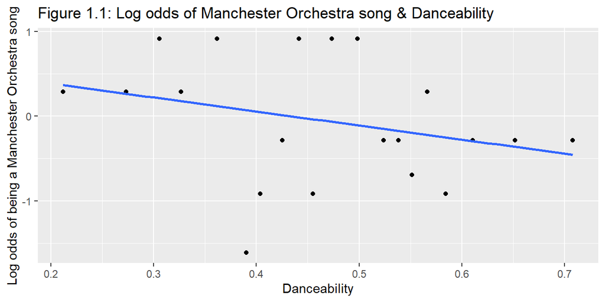

Here in figure 1.1, there is a weak linear relationship between danceability and the log odds of the song being by the Manchester Orchestra that is slightly negative. There are no outliers evident, though the point with log odds of -1.5 is worth looking at.

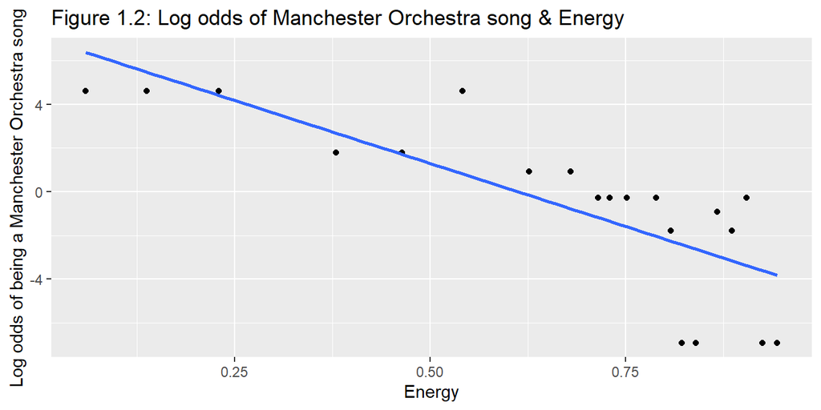

In figure 1.2, there is a strong, linear, negative relationship between the energy of a song and the log odds of it being a song by the Manchester Orchestra. There are no outliers in this plot.

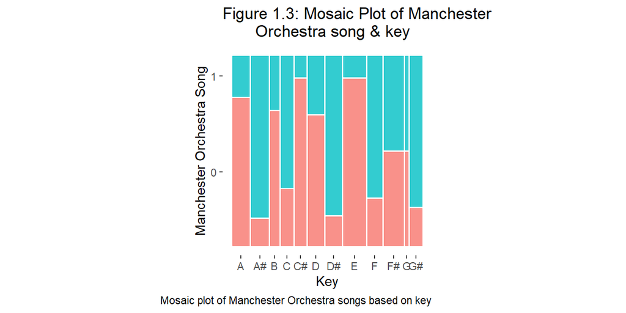

In figure 1.3, We can see that some keys have a higher frequency of being Manchester Orchestra songs, namely A#, C, D#, F, and G#. F# and G were about even, then the others had a lower frequency that that.

However, one of the keys, G, does not have enough data in it to hit the 5% mark, meaning it needs to be grouped with another key. After looking at the beta values for each key, G and F# share the same relationship with artist, so we will be combining them for the future.

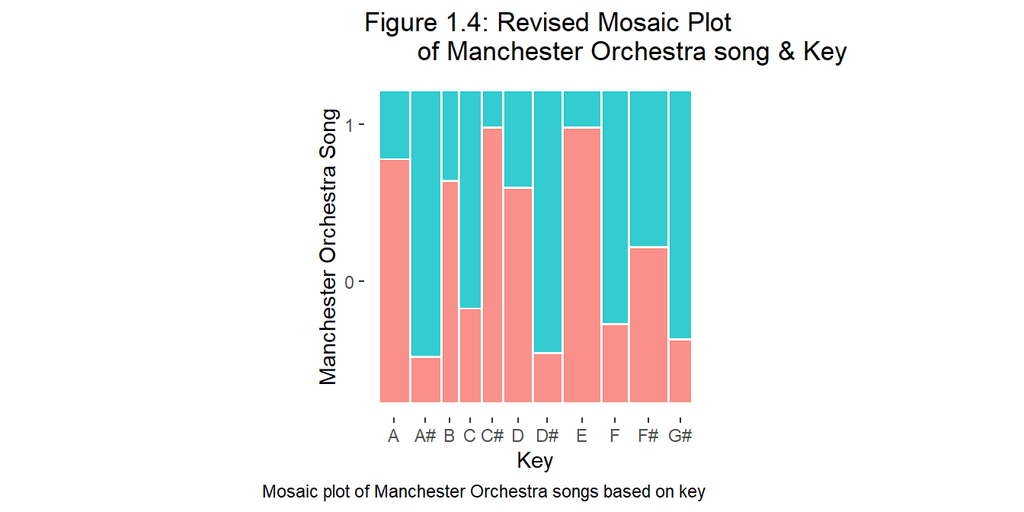

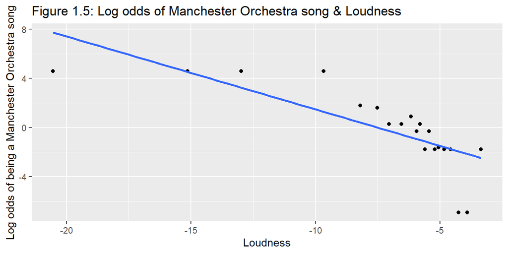

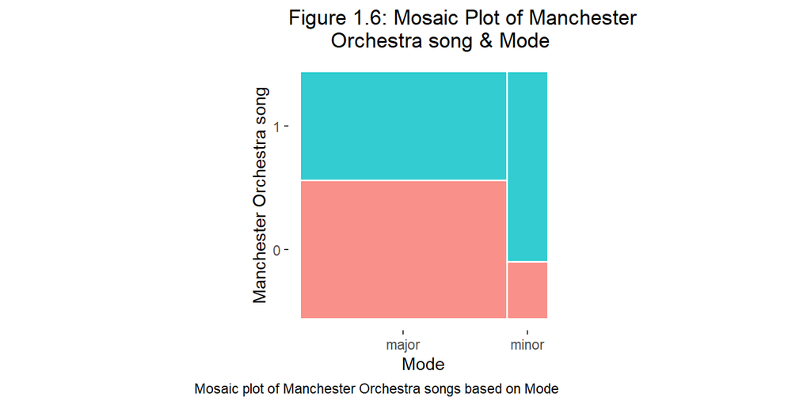

In figure 1.6, there is a higher frequency of songs with the minor mode being made by Manchester Orchestra. Overall, it is nearly split evenly on whether a song in the major key was made by the Manchester Orchestra or The Front Bottoms.

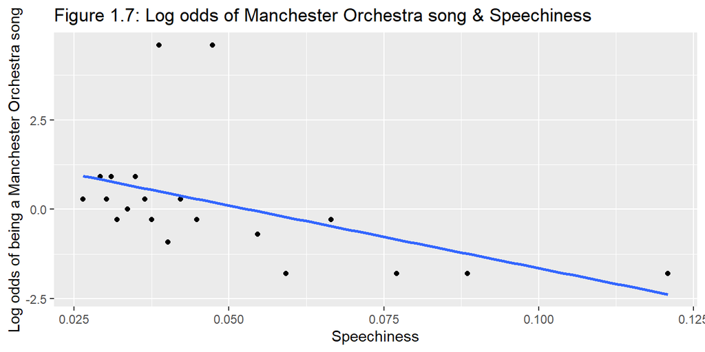

In figure 1.7, There is a strong, linear, negative relationship between speechiness and the log odds of being a Manchester Orchestra Song. There are two outliers, being the points with around 4.75 log odds.

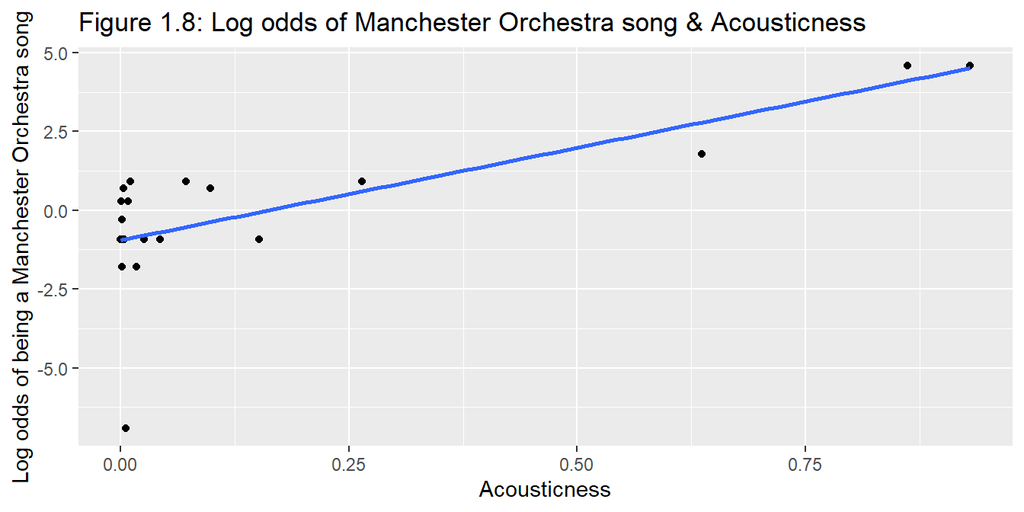

In figure 1.8, there is a strong, positive, linear relationship between acousticness and the log odds of being a song by the Manchester Orchestra. There is an outlier at log odds of about -6.75.

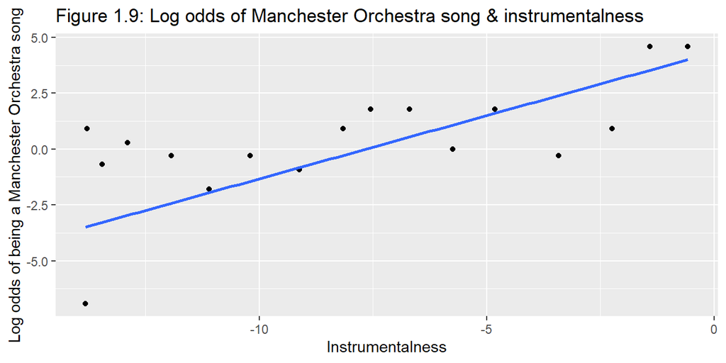

In figure 1.9, there is a medium, positive, linear relationship between instrumentalness and the log odds of being a Manchester Orchestra Song. There is one possible outlier on log odds -6.75.

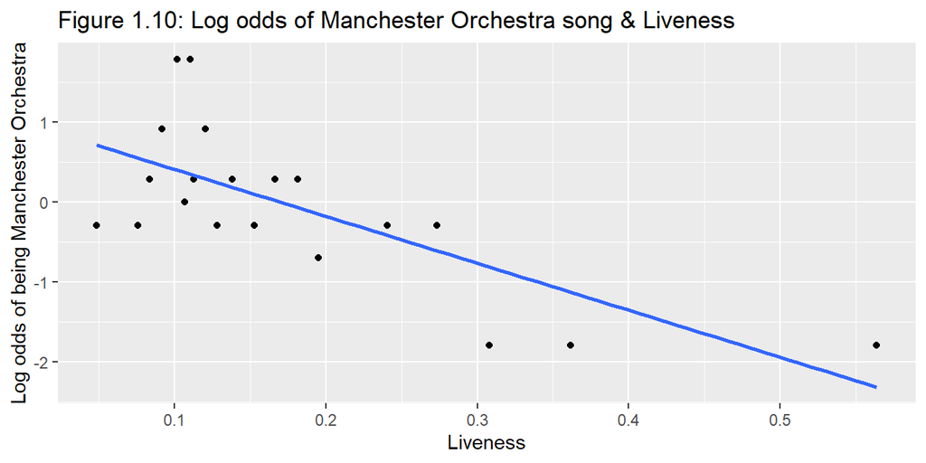

In figure 1.10, there is a strong, negative, linear relationship between liveness and log odds of being a Manchester Orchestra song. There are two points at around log odds 1.75 that are up for concern, but not quite outliers.

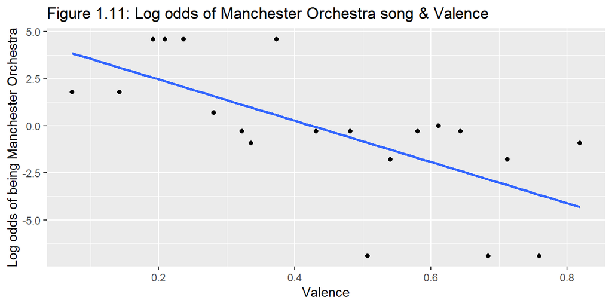

In figure 1.11, there is a strong, negative, linear relationship between valence and the log odds of being a Manchester Orchestra song. The three points with log odds around -6.75 are concerning, especially the point with valence 0.5.

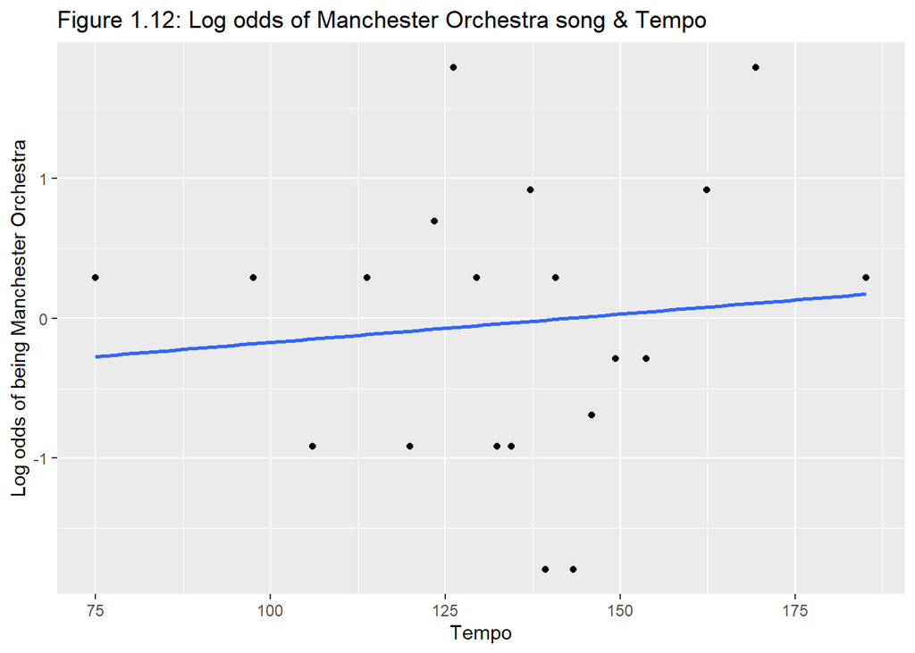

In figure 1.12, there is a very weak, positive, linear relationship between tempo and the log odds of being a Manchester Orchestra song.

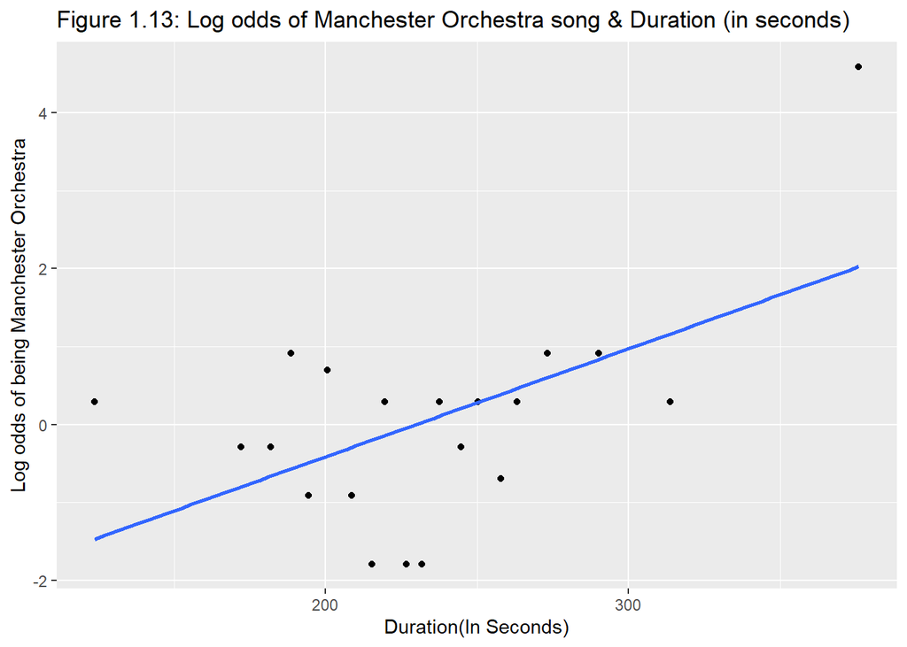

In figure 1.13, there is a medium, positive, linear relationship between duration(in seconds) and the log odds of being a Manchester Orchestra. There is one outlier above 4 log odds that should be examined.

After all of these plot have been analyzed, we can determine that the third condition of the shape of the relationship being reflected in the model passes, allowing us to now work with this data to create our own model to tackle the problem at hand.

## Section 2: Mode or Key?

In this section, we are looking to determine if there is a relationship between mode and key, and what combination of variables we want to include in our model.

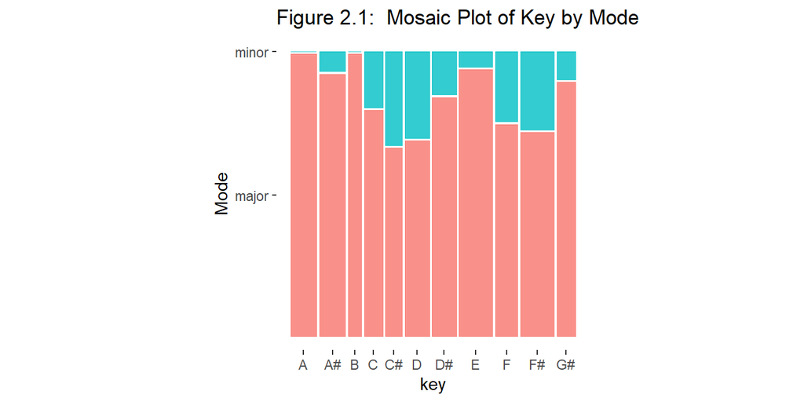

Based on this, the client is right that there is a relationship between mode and key, so we now need to determine which one we want included in our model. We will do this by comparing models where every other variable is held fixed, and seeing which is a better fit for the data by utilizing AIC.

After creating our models holding all other variables fixed, Model 1, which uses key, has a lower AIC of 163.13, than Model 2 which uses mode and has an AIC of 186.7, therefore signifying that key provides a better fit for the data than mode does. Therefore, we will only include key in our final model.

Next, we will look at more variables to see if there is again a relationship between them, and which should be included.

## Section 3: Energy, Acousticness, and Loudness

Now that we have determined which explanatory variables we want to use, we will now create a model to fit our data.

## Section 4: Building a Model

In this Section, we will now utilize all the variables we have determined to be important, and will now build the model that can be used to predict if a song is more likely to be a Manchester Orchestra song or The Front Bottoms’ song.

Final Model:

|  | Estimate | Std. Error | z value | Pr(>\|z\|) |
| --- | --- | --- | --- | --- |
| (Intercept) | -0.5368205 | 8.6873726 | -0.0617932 | 0.9507275 |
| danceability | 0.8120059 | 5.0064930 | 0.1621906 | 0.8711558 |
| energy | -8.9851735 | 5.1447617 | -1.7464703 | 0.0807293 |
| keyA# | 2.0761302 | 2.2655760 | 0.9163807 | 0.3594672 |
| keyB | -6.3104552 | 3.1986296 | -1.9728621 | 0.0485113 |
| keyC | 1.9050670 | 2.0897423 | 0.9116277 | 0.3619647 |
| keyC# | -5.6290642 | 3.4905086 | -1.6126774 | 0.1068146 |
| keyD | -7.9784475 | 3.2183115 | -2.4790787 | 0.0131722 |
| keyD# | -0.1357868 | 1.8546811 | -0.0732130 | 0.9416366 |
| keyE | -5.4549716 | 2.5974830 | -2.1000990 | 0.0357201 |
| keyF | -5.3460962 | 2.6849035 | -1.9911688 | 0.0464623 |
| keyF# | -1.7322622 | 1.8707327 | -0.9259806 | 0.3544561 |
| keyG# | 2.4830557 | 2.9706555 | 0.8358612 | 0.4032330 |
| loudness | -1.4979123 | 0.7513248 | -1.9936948 | 0.0461854 |
| speechiness | -28.7820050 | 21.3810734 | -1.3461441 | 0.1782561 |
| instrumentalness | 0.4112196 | 0.1490741 | 2.7584918 | 0.0058069 |
| liveness | 3.5771830 | 5.7033655 | 0.6272056 | 0.5305244 |
| valence | -11.4072889 | 5.5104406 | -2.0701228 | 0.0384408 |
| tempo | 0.0589616 | 0.0299892 | 1.9660955 | 0.0492876 |
| duration_s | 0.0092572 | 0.0111964 | 0.8268005 | 0.4083501 |

Using the sign on each explanatory variable, we can determine that any variables with positive coefficients are related to a song being from Manchester Orchestra, and the negative coefficients are related to a song being from The Front Bottoms. As a list, here are the variables that are related to each band:

The Front Bottoms: Energy, Keys: B, C#, D, D#, E, F, F#, loudness, speechiness, valence

Manchester Orchestra: danceability, Key: A#, C, G#, instrumentalness, liveness, tempo, and duration (in seconds)

Now that we have determined what variables point towards where a song comes from, we want to determine the measure of fit for the model, and in order to do this, we want to use the percent drop in deviance.

Our percent drop in deviance from the null model to our final model is 78.12%. This means that the final model has a deviance that is 78.12% smaller than that of the null model with no variables.

## Section 5: Making Predictions

In this section, we will determine our model’s ability to predict the artist of a song. We will use a confusion matrix, with a threshold of 0.6, to find this.

Table: Prediction vs Actual for Songwriter

|  | Actual: The Front Bottoms | Actual: Manchester Orchestra |
| --- | --- | --- |
| Predicted: The Front Bottoms | 67 | 5 |
| Predicted: Manchester Orchestra | 3 | 63 |

Our client would like at least 3 different numeric summaries to describe the preditiv abilities of our model, so we will use the true positive rate (TPR), true negative rate (TNR), and the accuracy as descriptors.

TPR: 92.65%

TNR: 95.71%

Accuracy: 94.20%

Our model has a TPR of 92.65%, a TNR of 95.71%, and an accuracy of 94.2%. This means that of the 68 songs that were Manchester Orchestra songs, our model correctly identified 63 of them. Out of the 70 songs that were The Front Bottoms songs, the model correctly identified 67 of them as such. Overall, for the 138 songs, we accurately identified who they were by 94.2% of the time (130/138).

Now that we have our model and know that it is effective in determining who a song was by, let us test this out.

## Section 6: Allentown

Given the new song Allentown, our client wishes for us to determine who it was written by. We will plug this into our model, rounding to two non-zero decimal places for our coefficients in the model.

Based on plugging the song into our model we get the predicted probability of the song Allentown being like a Manchester Orchestra song as approximately 1. Since the probability is approx. 1, this says this song is very much like a Manchester Orchestra song.

Based on looking at our model, and what variables point toward a song being like a Manchester Orchestra song, this predicted probability makes sense, as the song has low energy, is quiet, has a fast tempo, and the key is C. These are all characteristics that point towards being a song similar to Manchester Orchestra songs.